# DSE5002Project01 - 11/24/24

# Calculation finding the average salary_in_USD by employment_type.

```r
emp_type_salary <- salary_data %>%
  group_by(employment_type) %>%
  summarize(avg_emptype_salary = mean(salary_in_usd, na.rm = TRUE))
print(emp_type_salary)
```

```
## # A tibble: 4 × 2
##   employment_type avg_emptype_salary
##   <fct>                        <dbl>
## 1 CT                         184575
## 2 FL                          48000
## 3 FT                         113468.
## 4 PT                          33070.
```

# Bar plot showing the average salary_in_USD by employment_type.

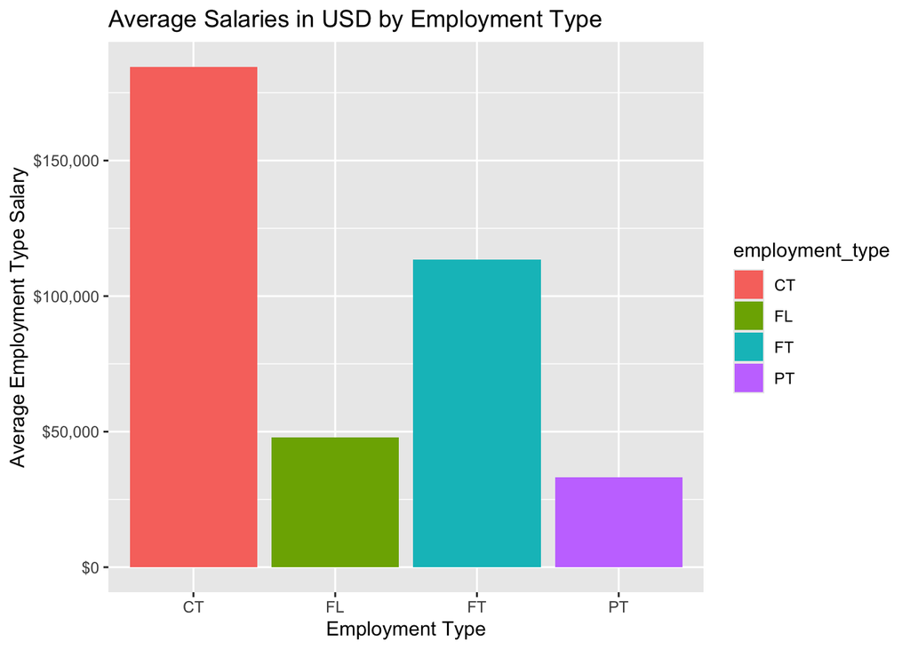

```r
ggplot(emp_type_salary, aes(x = employment_type, y = avg_emptype_salary, fill = employment_type)) +
  geom_col() +
  scale_y_continuous(labels = scales::label_dollar()) +
  labs(title = "Average Salaries in USD by Employment Type", x = "Employment Type",
       y = "Average Employment Type Salary")
```

# Calculation finding the average salary_in_USD by employee residences focusing on the countries with at least 10 records. # Several other countries were listed but did not have significant enough data for the CEO.

```r
empresidence_salaries <- salary_data %>%
  group_by(employee_residence) %>%
  summarise(mean_empresidence_salaries = mean(salary_in_usd, na.rm = TRUE),
            count = n()) %>%
  arrange(desc(mean_empresidence_salaries)) %>%
  filter(count >= 10) %>%
mutate(mean_empresidence_salaries = as.numeric(mean_empresidence_salaries))
print(empresidence_salaries)
```

```
## # A tibble: 8 × 3
##   employee_residence mean_empresidence_salaries count
##   <fct>                                   <dbl> <int>
## 1 US                                    149194.   332
## 2 CA                                     97085.    29
## 3 DE                                     85553.    25
## 4 GB                                     81403.    44
## 5 FR                                     59887.    18
## 6 ES                                     57593.    15
## 7 GR                                     56331.    13
## 8 IN                                     37322.    30
```

# A corresponding plot showing the average salary_in_USD by employee residences focusing on the countries with at least 10 records.

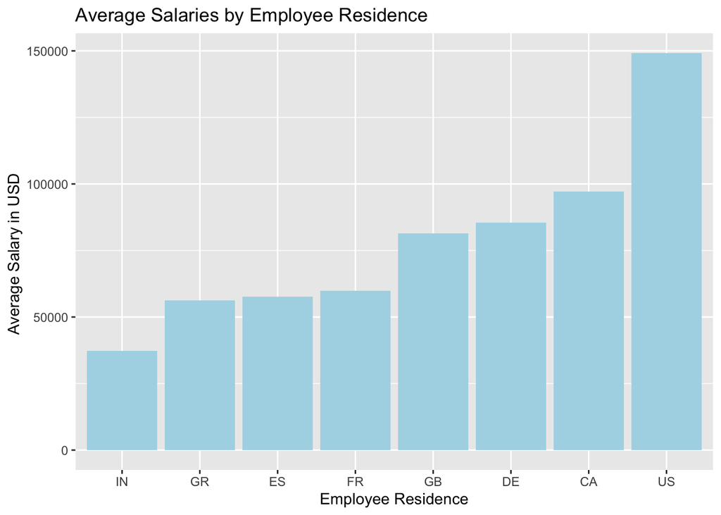

```r
ggplot(empresidence_salaries, aes(x = reorder(employee_residence, mean_empresidence_salaries),
        y = mean_empresidence_salaries)) +
         geom_col(fill = "lightblue") +
         labs(title = "Average Salaries by Employee Residence", x = "Employee Residence",
              y = "Average Salary in USD ")
```

```r
#US employees are making more on average at about $150,000
```

#Calculation finding the count of records by employee_residence, focusing on the countries with at least 10 records

```r
residence_count<-salary_data %>%
  group_by(employee_residence) %>%
  summarise(count = n()) %>%
  arrange(desc(count)) %>%
  filter(count >= 10)
print(residence_count)
```

```
## # A tibble: 8 × 2
##   employee_residence count
##   <fct>              <int>
## 1 US                   332
## 2 GB                    44
## 3 IN                    30
## 4 CA                    29
## 5 DE                    25
## 6 FR                    18
## 7 ES                    15
## 8 GR                    13
```

```r
# most of the employees in this dataset are US based, ideal for the CEO looking to find new talent.
```

# Corresponding plot showing the distribution of employees residences focusing on the countries with at least 10 records.

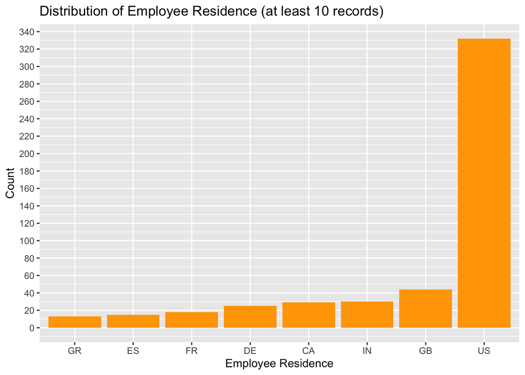

```r
ggplot(residence_count, aes(x = reorder(employee_residence, count),
  y = count)) + geom_col(fill = "orange") +
  scale_y_continuous(breaks=seq(0,400,by=20)) +
  labs(title = "Distribution of Employee Residence (at least 10 records)", x = "Employee Residence",
       y = "Count")
```

# Calculation finding the count of the various company_locations with at least 10 records.

```r
count_comp_loc<-salary_data%>%
  group_by(company_location)%>%
  summarise(count = n())%>%
  arrange(desc(count))%>%
  filter(count >= 10)
print(count_comp_loc)
```

```
## # A tibble: 8 × 2
##   company_location count
##   <fct>            <int>
## 1 US                 355
## 2 GB                  47
## 3 CA                  30
## 4 DE                  28
## 5 IN                  24
## 6 FR                  15
## 7 ES                  14
## 8 GR                  11
```

```r
# similarly to the employee_residence, most of company locations of the employees in this data set
# are employed by US companies.
```

# Corresponding plot of the count of company_locations with at least 10 records.

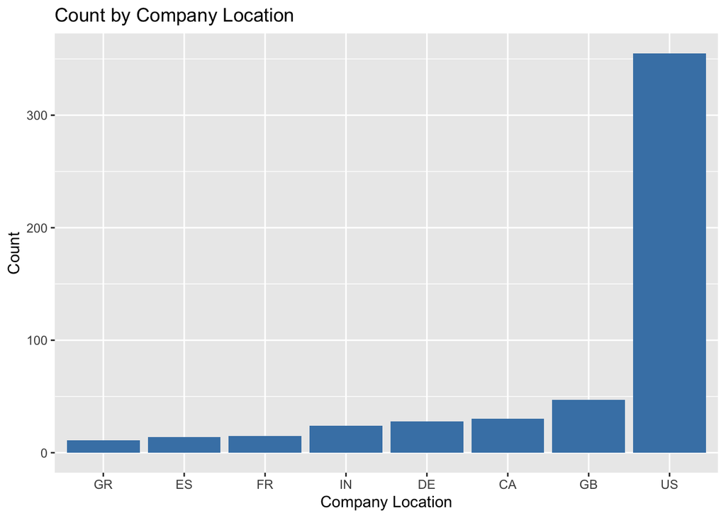

```r
ggplot(count_comp_loc, aes(x = reorder(company_location, count), y = count)) +
  geom_col(fill = "steelblue") +
  labs(title = "Count by Company Location",
       x = "Company Location", y = "Count")
```

# Calculation finding the average salary_in_usd by company_location.

```r
salary_by_comp_location <- salary_data %>%
  group_by(company_location) %>%
  summarize(avg_salary_by_comploc = mean(salary_in_usd, na.rm = TRUE)) %>%
  arrange(desc(avg_salary_by_comploc)) %>%
  slice_head(n = 10)
print(salary_by_comp_location)
```

```
## # A tibble: 10 × 2
##    company_location avg_salary_by_comploc
##    <fct>                            <dbl>
##  1 RU                             157500
##  2 US                             144055.
##  3 NZ                             125000
##  4 IL                             119059
##  5 JP                             114127.
##  6 AU                             108043.
##  7 AE                             100000
##  8 DZ                             100000
##  9 IQ                             100000
## 10 CA                              99824.
```

```r
# Russian companies have the highest average salary in USD, followed by the U.S..
```

# Bar plot of the average salary_in_usd by company_location.

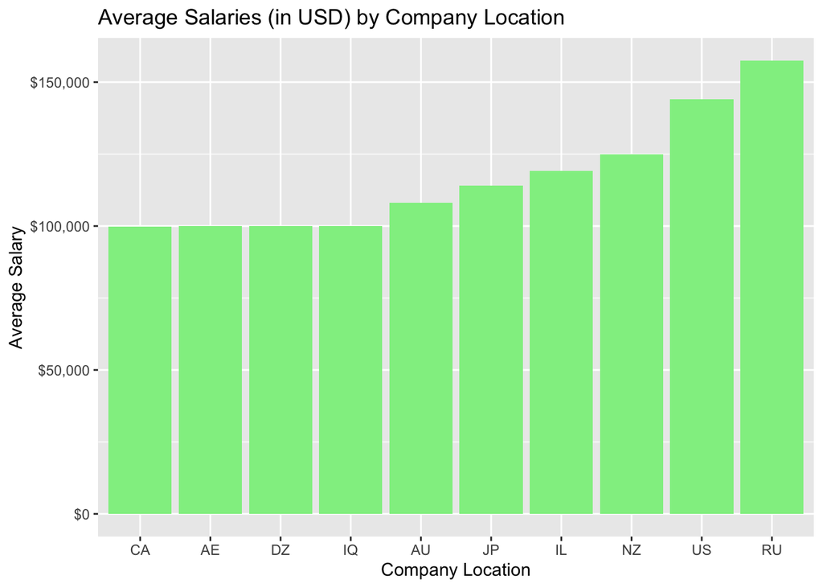

```r
ggplot(salary_by_comp_location, aes(x = reorder(company_location, avg_salary_by_comploc),
                                    y = avg_salary_by_comploc)) +
  geom_col(fill = "lightgreen") +
  scale_y_continuous(labels = scales::label_dollar()) +  # Apply dollar formatting here
  labs(title = "Average Salaries (in USD) by Company Location",
       x = "Company Location", y = "Average Salary")
```